# JP tourists Number Prediction 201507

小新

2015年8月4日

# 1 总体情况

## 1.1 关键方法和结果

1. 采用了六种方法预测：

   ＋ 基于Y2Y增长绝对数值的线性回归预测

   ＋ 基于Y2Y增长绝对数值的一阶差分预测

   ＋ 基于M2M月度一阶差分的线性回归预测

   ＋ 基于M2M月度一阶差分的保守预测

   ＋ 基于M2M月度二阶差分预测

   ＋ 基于百度指数的线性回归预测
2. 主要问题：仍然找不到很合适的百度指数
3. 请交叉验证
4. 自动报告文档，格式还不完善。

## 1.2 关键参数

# 2 仿真过程

## 2.1 Overview

- 总的方法分为三个维度
  - Y2Y增长量在2015M1至M6中的相关性规律（Diff12 groupby month）
  - M2M增长量在2008至2015年中的相关性规律（Diff1 groupby year）
  - 百度指数：在最近1-2年中与日本旅游人数的相关性规律

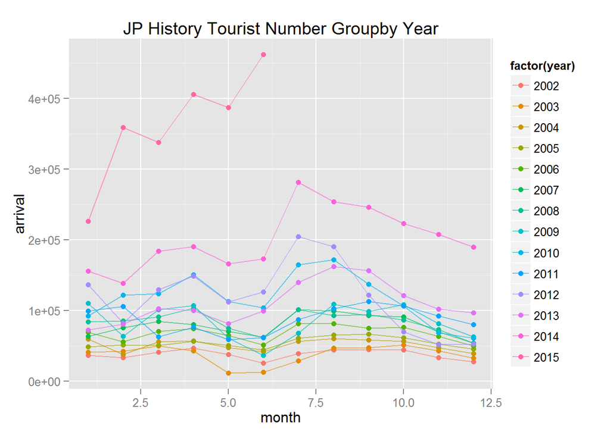

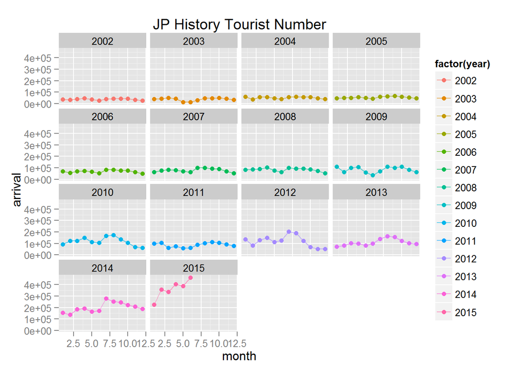

## 2.2 基于Y2Y增长绝对数值的线性回归预测

### 2.2.1 直观overview

- 直观上看Diff12 在各个月份之间是存在相关性的，个个月份的变化在最近几年是比较一致。

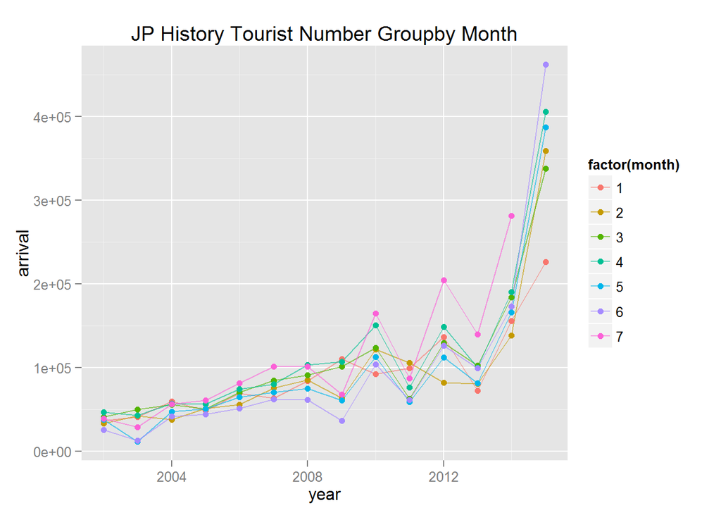

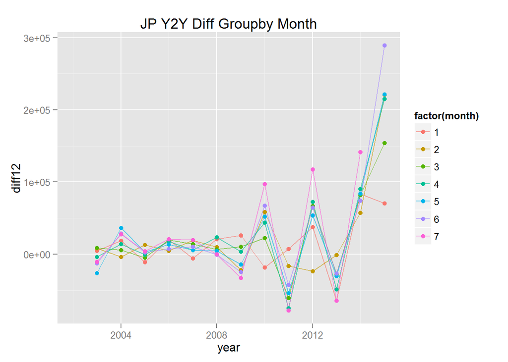

### 2.2.2 相关性分析

- 研究“Y2Y增长额度Diff12（M7）” ，发现Diff12（M7）与Diff12（M56）呈现很强的相关性，高达0.9950013,因此考虑使用Linear Regression的方法，通过Diff12（M56）来预测Diff12（M7）。

Y2Y Diff12（M7）Coefficient Correlation

| m1 | m2 | m3 | m4 | m5 | m6 | m7 | m1a2 | m34 | m45 | m56 |
| --- | --- | --- | --- | --- | --- | --- | --- | --- | --- | --- |
| 0.5848692 | 0.5838633 | 0.9233243 | 0.9491152 | 0.9879658 | 0.9896291 | 1 | 0.7704184 | 0.9433498 | 0.975004 | 0.9950013 |

- 下面图1直观展示了二者的线性关系，图2展示了Diff12（M7）结果，图3展示了误差情况
- 呈现强相关的都是在Diff12（M56）低位，因为2015 Diff12（M56）暴增，在高位是否与Diff12（M7）仍然呈现线性关系是个问题
- 因此，本方法相对来说比较“激进”

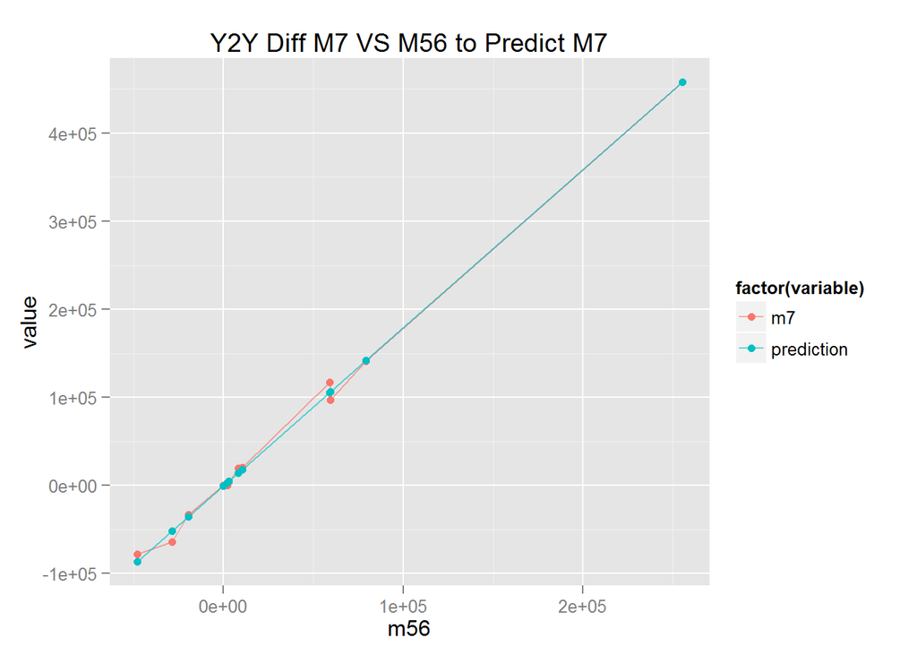

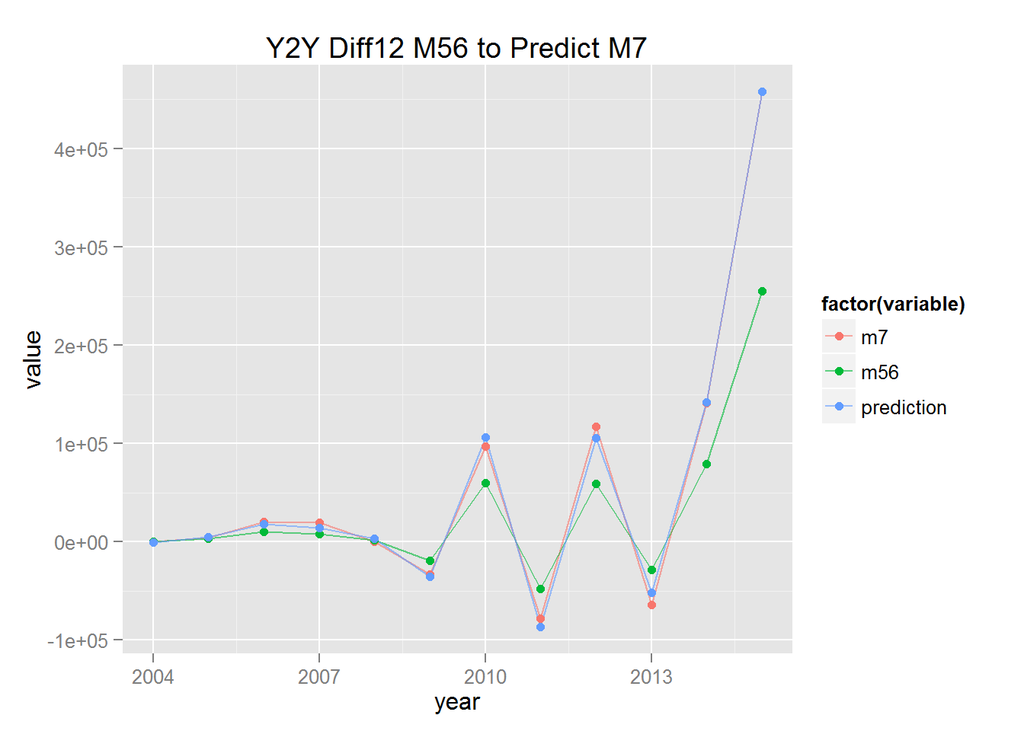

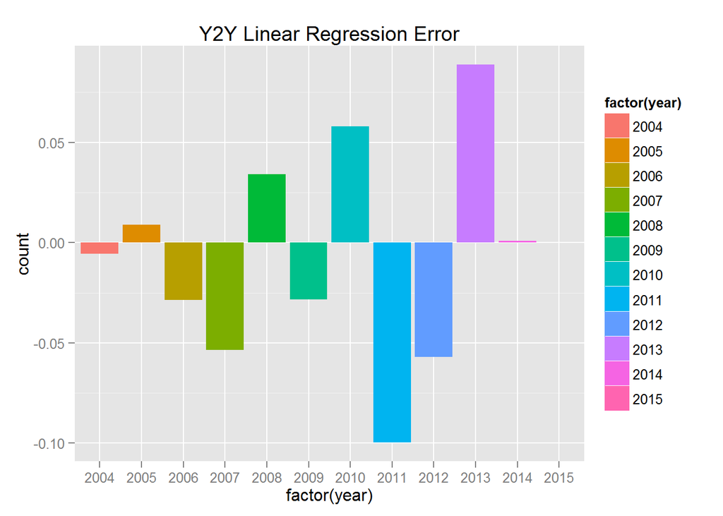

### 2.2.3 结果

基于Y2Y增长绝对数值的线性回归预测

| date | methdology | floor | cap | bestguess |
| --- | --- | --- | --- | --- |
| 2015-07-01 | Y2Y Diff LR with M56 | 559616.5 | 671596.7 | 627238.7 |

## 2.3 基于Y2Y增长绝对数值的一阶差分预测

### 2.3.1 方法论

- 直观上看Diff12（M7）与Diff12（M56）、Diff12（M6）之间是同趋势变化的，本方法旨在找到与Diff12（M7）变化趋势最相近的变量指标。判断标准是最小化：Variance of Diff12（M7）- Diff12（Mxx）。
- 从下图中可以看到，Diff12（M6）和Diff12（M7）的差值是variance波动率几乎是0
- 这是一个非常好的性质，我们可以假定，Diff12（M6）和Diff12（M7）一阶差分在各个年度是不变的。
- 因此，我们用2014年Diff12（M7）- Diff12（M6）作为2015年差值，再加上2015 Diff12 M6可以得到2015 Diff12（M7）

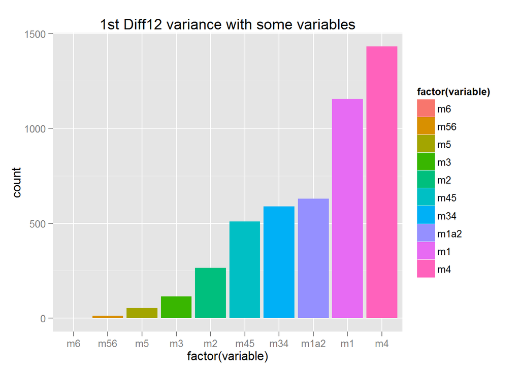

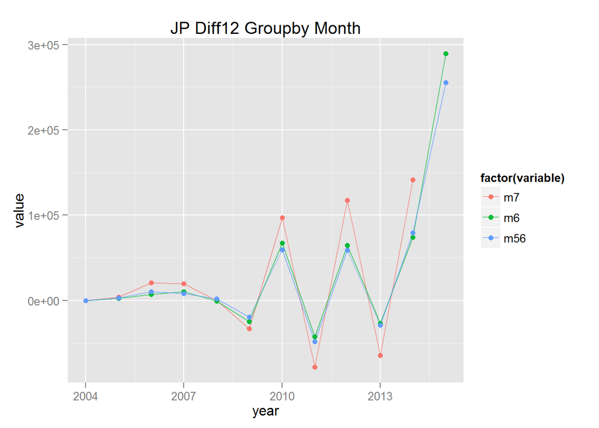

### 2.3.2 结果

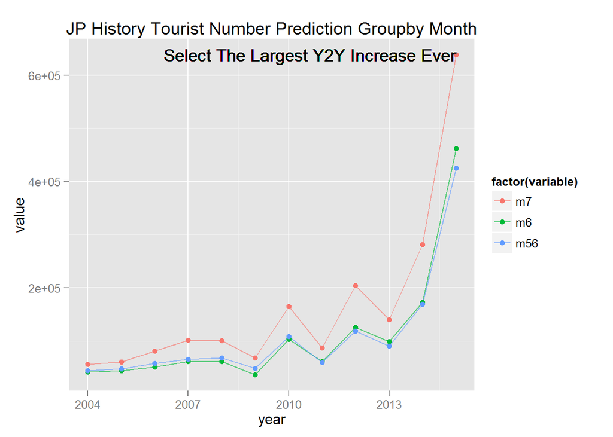

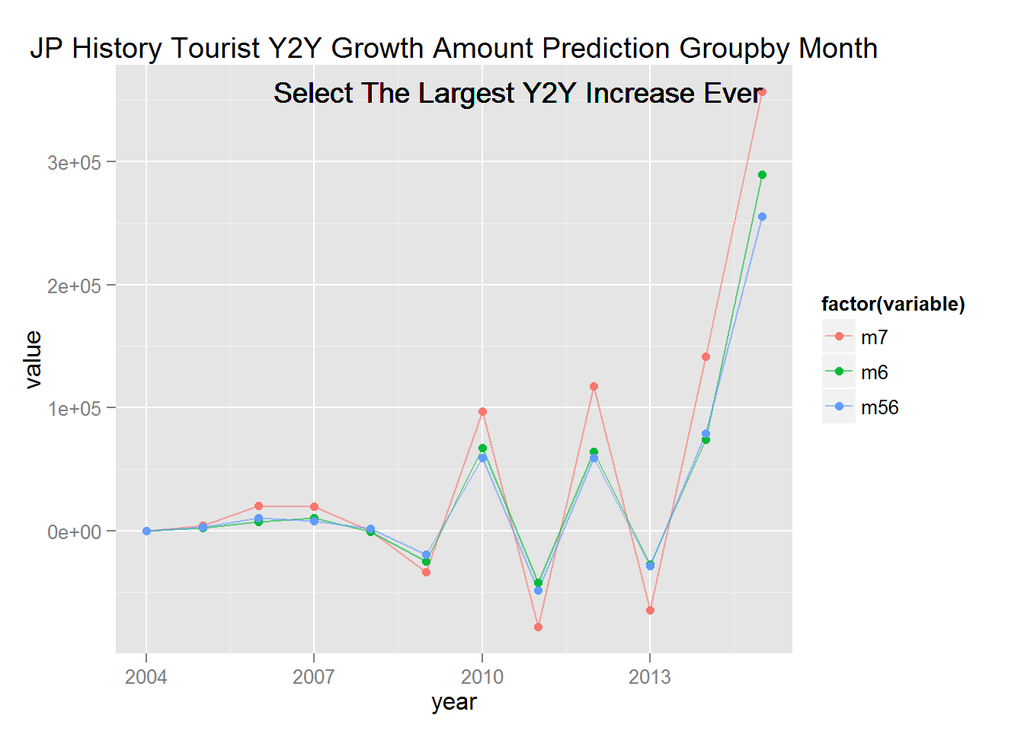

基于Y2Y增长绝对数值的一阶差分预测

|  | date | methdology | floor | cap | bestguess |
| --- | --- | --- | --- | --- | --- |
| 2 | 2015-07-01 | Y2Y Diff 1st Order M6 | 533185 | 637917 | 637917 |

## 2.4 基于M2M月度一阶差分的线性回归预测

### 2.4.1 方法论

- 本方法研究一阶差分Diff1，也就是M7-M6，也就是M2M月度增长量的规律
- M2M的话月度之间相关性不强，主要看年度之间的M7-M6是否出现相关性，因此主要看groupby Year的图
- 下图1 2中，可以看到M2M一阶差分Diff(M7-M6)在各个年度还是呈现一定相关性的，特别是2014 2012 2010年度
- M6-M5和M5-M4历年的数据也不错

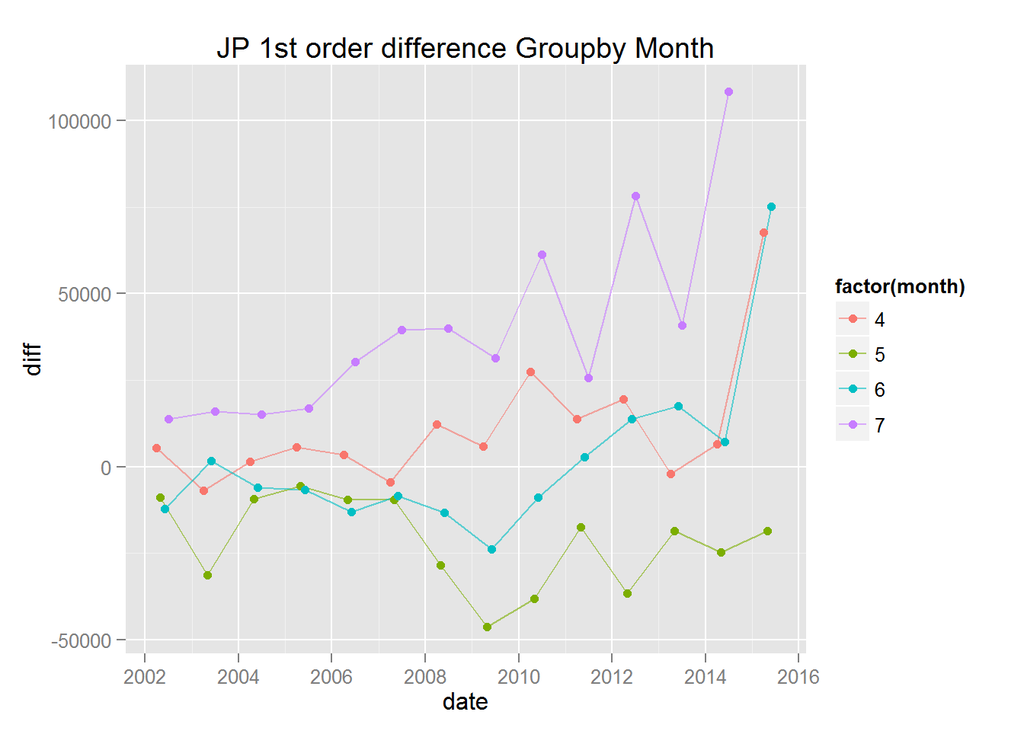

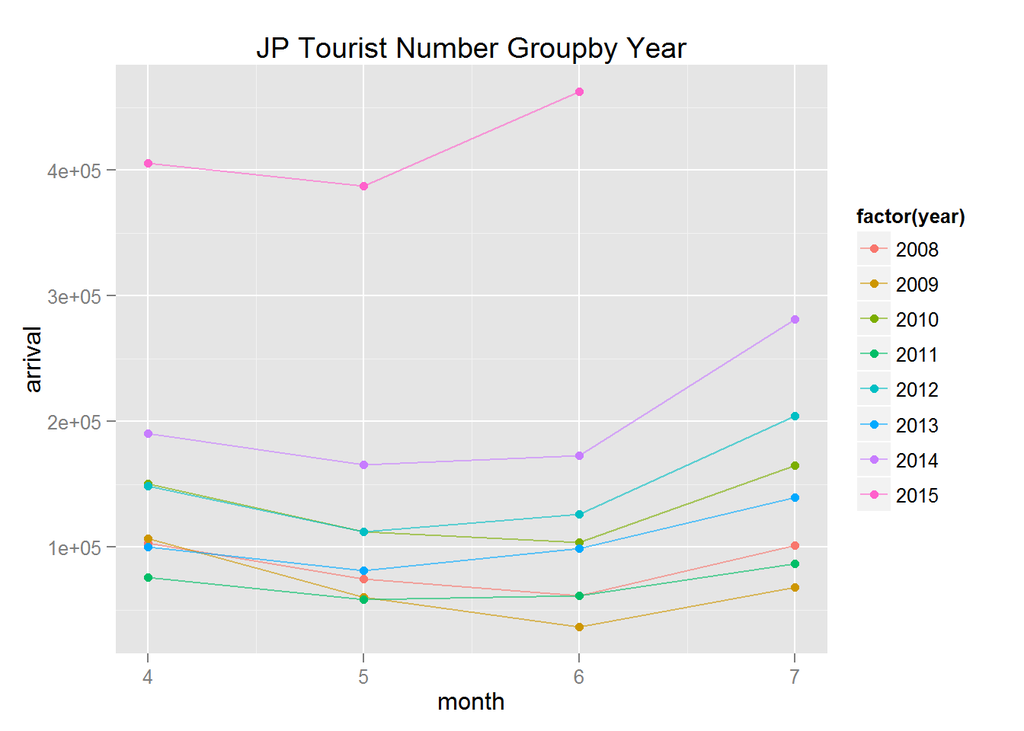

### 2.4.2 有关回归

基于M2M月度一阶差分的线性回归预测

| m7 | m6 | m56 | diff6 | diff56 |
| --- | --- | --- | --- | --- |
| 0.9952227 | 0.9840675 | 0.9845134 | 0.9782843 | 1 |

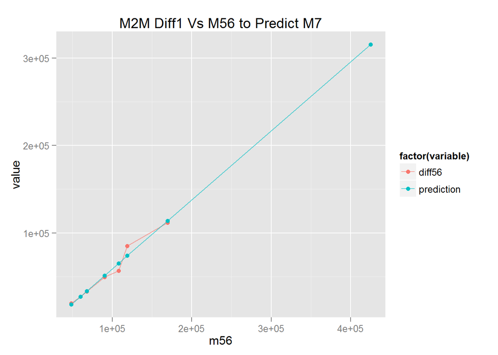

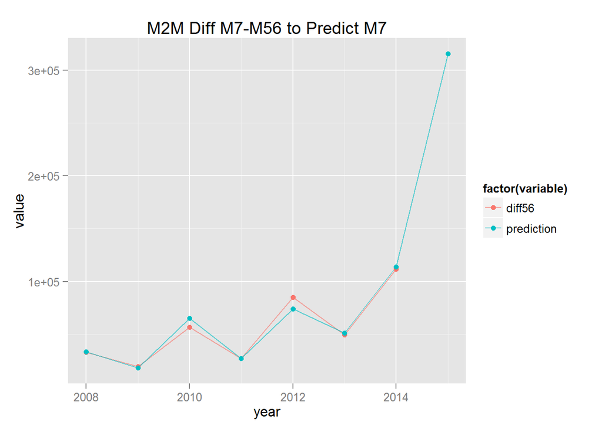

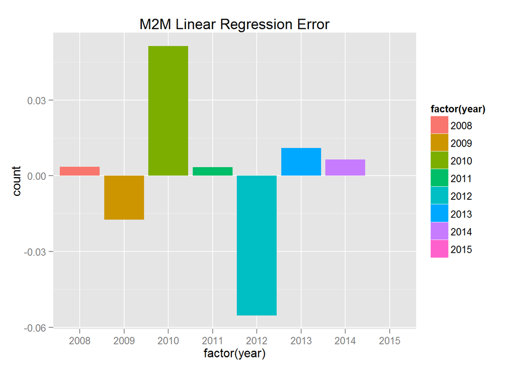

### 2.4.3 结果

基于M2M月度一阶差分的线性回归预测

|  | date | methdology | floor | cap | bestguess |
| --- | --- | --- | --- | --- | --- |
| 8 | 2015-07-01 | M2M 1st Order Diff LR with M56 | 731726.3 | 751476.5 | 740184.9 |

## 2.5 基于M2M月度一阶差分的保守预测

## 2.5.1 方法论

- 一阶差分保守预测，就是简单的认为M7-M6是多年保持不变的，去年M2M涨多少，今年继续涨多少。

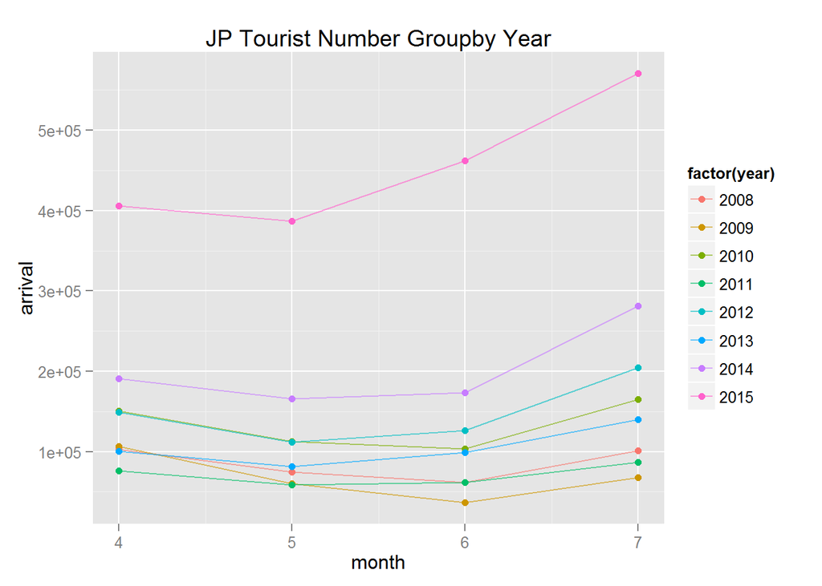

### 2.5.2 结果

基于M2M月度一阶差分的保守预测

|  | date | methdology | floor | cap | bestguess |
| --- | --- | --- | --- | --- | --- |
| 4 | 2015-07-01 | M2M 1st Order Diff Staionary M6 | NA | NA | 570563 |

## 2.6 基于M2M月度二阶差分预测

### 2.6.1 方法论

- 基于M2M月度二阶差分预测研究对象是M2M的增长量（M7-M6）的增长量，认为M2M的增长量（M7-M6）的增长量是保持不变的
- Diff M7(2015) - Diff M6(2015)=Diff M7(2014) - Diff M6(2014)
- Diff M7(2015)=Diff M6(2015)+Diff M7(2014)-Diff M6(2014)

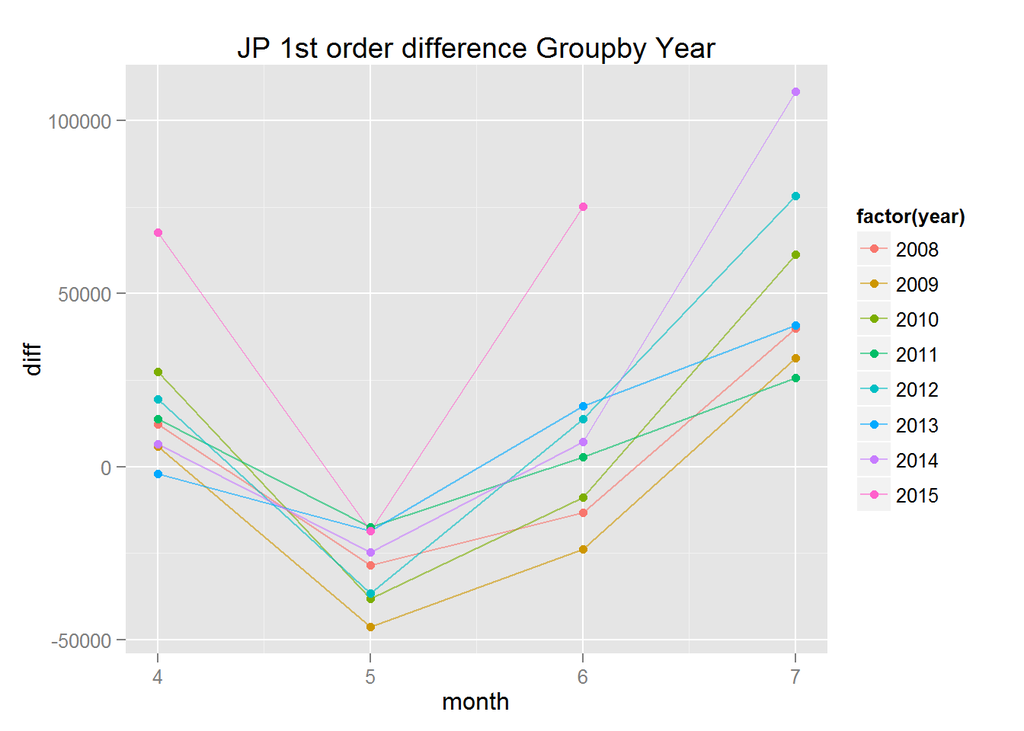

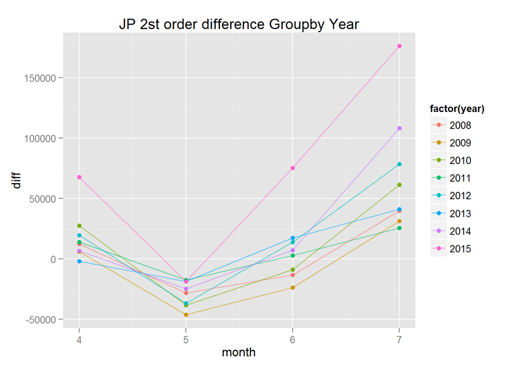

### 2.6.3 结果

基于M2M月度二阶差分预测

|  | date | methdology | floor | cap | bestguess |
| --- | --- | --- | --- | --- | --- |
| 5 | 2015-07-01 | M2M 2nd Order Diff with M6 | NA | NA | 638401 |

## 2.7 基于百度指数的线性回归预测

### 2.7.1 方法论

- 因变量：
  - 在所有的百度指数中，寻找2014年以来，与日本旅游人数相关性最强的关键词作为预测依据
- 哑变量：
  - newyear：用来解决新年在1月还是2月的问题
  - mars：用来解决韩国旅游人数在6月份暴跌，日本暴涨的问题

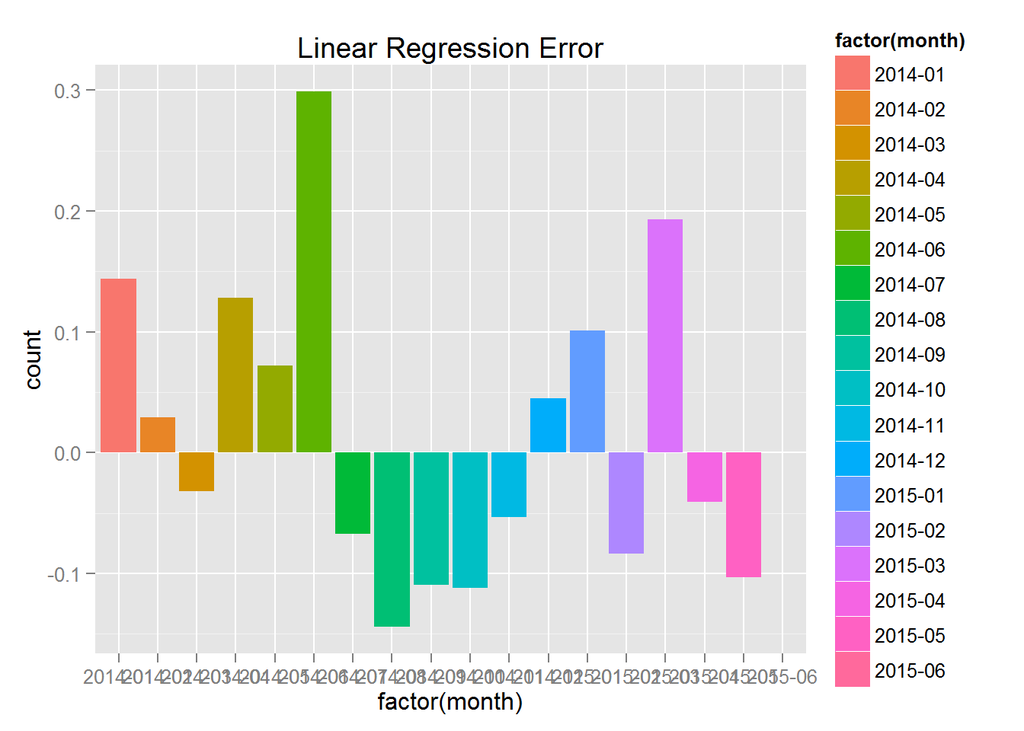

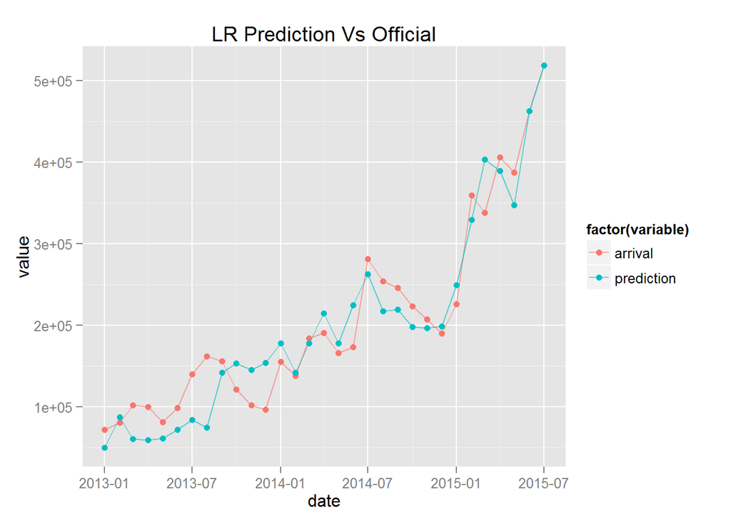

### 2.7.2 结果

基于百度指数的线性回归预测

|  | date | methdology | floor | cap | bestguess |
| --- | --- | --- | --- | --- | --- |
| 31 | 2015-07-01 | LR with gwgl mars | NA | NA | 518353.2 |

# 3 仿真结果

最终预测结果汇总表

| date | methdology | floor | cap | bestguess |
| --- | --- | --- | --- | --- |
| 2015-07-01 | Y2Y Diff LR with M56 | 559616.5 | 671596.7 | 627238.7 |
| 2015-07-01 | Y2Y Diff 1st Order M6 | 533185.0 | 637917.0 | 637917.0 |
| 2015-07-01 | M2M 1st Order Diff LR with M56 | 731726.3 | 751476.5 | 740184.9 |
| 2015-07-01 | M2M 1st Order Diff Staionary M6 | NA | NA | 570563.0 |
| 2015-07-01 | M2M 2nd Order Diff with M6 | NA | NA | 638401.0 |
| 2015-07-01 | LR with gwgl mars | NA | NA | 518353.2 |
| 2015-07-01 | Method Mean | NA | NA | 622109.6 |
| 2015-07-01 | Final Result | NA | NA | 660935.4 |

2015-07-01 Result Analysis

|  | date | 2015-7 | 2015-6 | 2014-7 | M2M | Y2Y | mmratio | yyratio | korea |
| --- | --- | --- | --- | --- | --- | --- | --- | --- | --- |
| 151 | 2014-07-01 | 281309.0 | 173046 | 139905 | 108263.0 | 141404.0 | 1.6256313 | 2.010714 | 692053 |
| 152 | 2014-08-01 | 253802.0 | 281309 | 162288 | -27507.0 | 91514.0 | 0.9022178 | 1.563899 | 757683 |
| 153 | 2014-09-01 | 246105.0 | 253802 | 156201 | -7697.0 | 89904.0 | 0.9696732 | 1.575566 | 564078 |
| 154 | 2014-10-01 | 223214.0 | 246105 | 121335 | -22891.0 | 101879.0 | 0.9069869 | 1.839651 | 562278 |
| 155 | 2014-11-01 | 207462.0 | 223214 | 101940 | -15752.0 | 105522.0 | 0.9294309 | 2.035138 | 460671 |
| 156 | 2014-12-01 | 190000.0 | 207462 | 96572 | -17462.0 | 93428.0 | 0.9158304 | 1.967444 | 420501 |
| 157 | 2015-01-01 | 226300.0 | 190000 | 155605 | 36300.0 | 70695.0 | 1.1910526 | 1.454323 | 394345 |
| 158 | 2015-02-01 | 359100.0 | 226300 | 138236 | 132800.0 | 220864.0 | 1.5868316 | 2.597731 | 516787 |
| 159 | 2015-03-01 | 338200.0 | 359100 | 184064 | -20900.0 | 154136.0 | 0.9417989 | 1.837404 | 515130 |
| 160 | 2015-04-01 | 405800.0 | 338200 | 190558 | 67600.0 | 215242.0 | 1.1998817 | 2.129535 | 641610 |
| 161 | 2015-05-01 | 387200.0 | 405800 | 165784 | -18600.0 | 221416.0 | 0.9541646 | 2.335569 | 618083 |
| 162 | 2015-06-01 | 462300.0 | 387200 | 173046 | 75100.0 | 289254.0 | 1.1939566 | 2.671544 | 315095 |
| 163 | 2015-07-01 | 660935.4 | 462300 | 281309 | 198635.4 | 379626.4 | 1.4296677 | 2.349500 | NA |

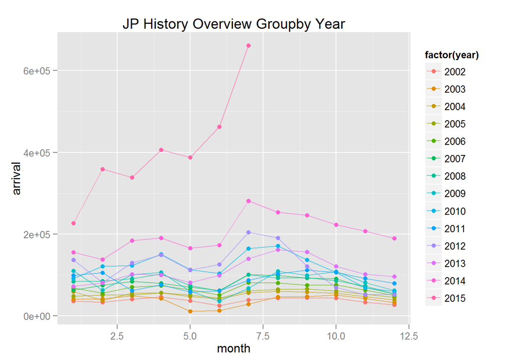

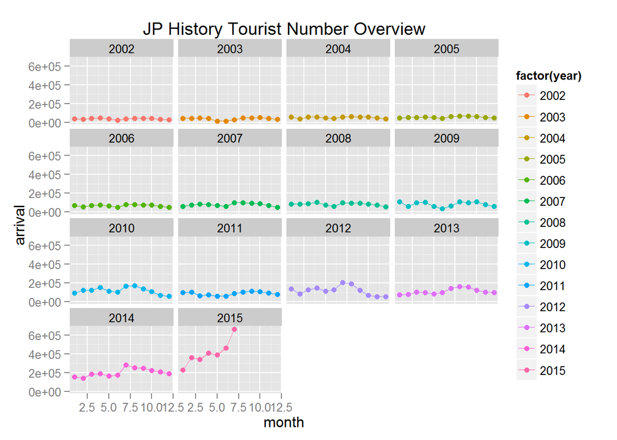

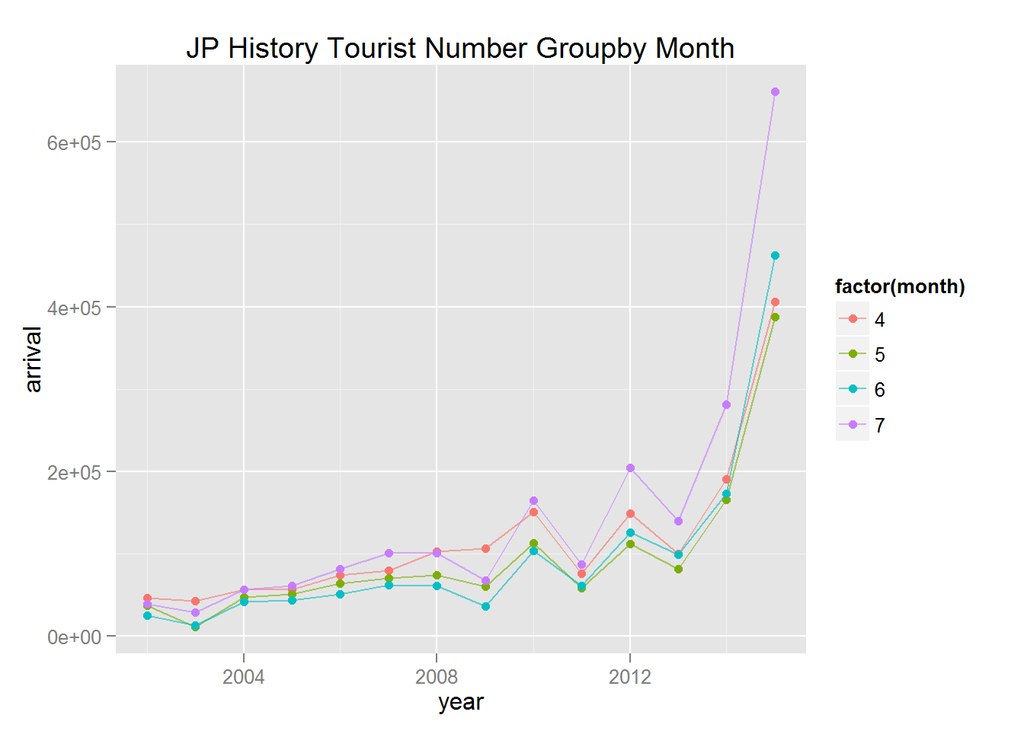

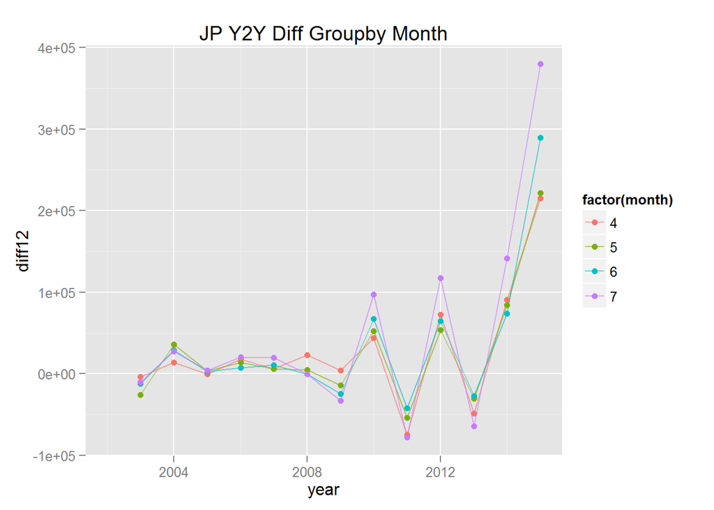

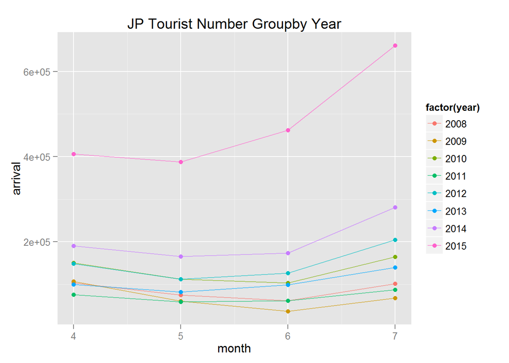

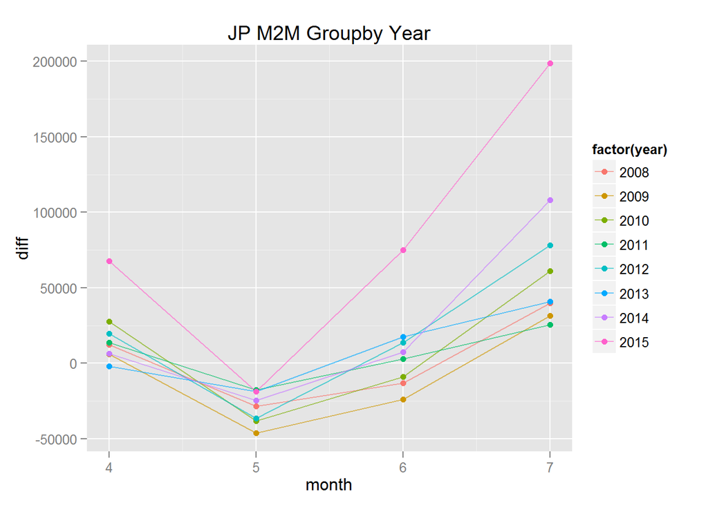